# Phenotyping of SARS-CoV-2-specific T cells

11 May 2021

## Introduction

- The current COVID-19 pandemia, caused by the SARS-CoV-2 virus, has caused the death of more than 3.2 million people worldwide.
- Studies in convalescent patients has shown a decline of antibody-mediated response a few months after infection.
- CD8+ T cells are critical for efficient clearance of virus-infected cells and long-term protection against SARS-CoV-2.
- Saini *et al* have analyzed T cell recognition towards SARS-CoV-2-derived peptides in COVID-19 patients and healthy individuals using DNA-barcoded pMHC multimers combined with a T cell phenotyping.

## Objective

- In this project, we analyze the immunophenotypes of CD8 T cells that can recognize peptides from the SARS-CoV-2 genome
- We compare COVID-19 patients with healthy donors (HD) never exposed to the virus.
- Furthermore, we compare the phenotypes to the severity of the disease.
- We also compare the phenotype of the SARS-CoV-2 specific CD8 T cells with T cells that recognize common viruses.

[figure not shown]

Fig. 1-Experimental pipeline for T cell identification from COVID-19 patients.

## Overview

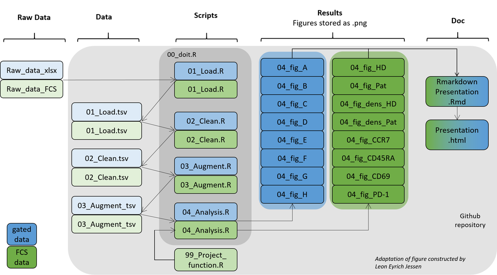

## Materials and methods

### Phenotype data

- Phenotyping of immune cells provides imformation abouts the activation status of the cells
- This is obtained through antibody staining and flow cytometry, which transforms a fluorescent signal into a voltage.
- Cell populations of specific phenotype is gated in FlowJo software, and frequencies of positive cells can afterwards exported as an .xlsx file

## Gated data: Raw

- The gated dataset is obtained from S. K. Saini *et al., Sci. Immunol.* (2021)

```
## # A tibble: 82 x 25
##    SampleID  Hospital_status `lymphocytes/sin… `lymphocytes/si… `lymphocytes/si…
##    <chr>     <chr>           <chr>             <chr>            <chr>
##  1 Patient_1 Hospitalized    28.7              20.399999999999… 1.66
##  2 Patient_2 Hospitalized    12.5              84.1             44.9
##  3 Patient_3 Hospitalized    27.3              91.2             16.7
##  4 Patient_4 Hospitalized    5.9               23.3             8.4600000000000…
##  5 Patient_5 Hospitalized    16.8              40               11.2
##  6 Patient_6 Hospitalized    4.83              49.2             25.9
##  7 Patient_7 NA              NA                76.7             32.1
##  8 Patient_8 Hospitalized    1.94              45.6             5.41
##  9 Patient_9 Hospitalized    3.76              34.1             6.15
## 10 Patient_… Hospitalized    1.69              31.5             12
## # … with 72 more rows, and 20 more variables:
## #   lymphocytes/singlet/live_cells/CD3+/CD8+/SARS_multimer+/CD69 <chr>,
## #   lymphocytes/singlet/live_cells/CD3+/CD8+/SARS_multimer+/PD-1 <chr>,
## #   lymphocytes/singlet/live_cells/CD3+/CD8+/SARS_multimer+/HLA-DR <chr>,
## #   lymphocytes/singlet/live_cells/CD3+/CD8+/SARS_multimer+/CD27 <chr>,
## #   lymphocytes/singlet/live_cells/CD3+/CD8+/SARS_multimer+/CD57 <chr>,
## #   lymphocytes/singlet/live_cells/CD3+/CD8+/SARS_multimer+/CD45RA-_CCR7+ <chr>,
## #   lymphocytes/singlet/live_cells/CD3+/CD8+/SARS_multimer+/CD45RA-_CCR7- <chr>,
## #   lymphocytes/singlet/live_cells/CD3+/CD8+/SARS_multimer+/CD45RA+_CCR7- <chr>,
## #   lymphocytes/singlet/live_cells/CD3+/CD8+/SARS_multimer+/CD45RA+_CCR7+ <chr>,
## #   lymphocytes/singlet/live_cells/CD3+/CD8+/SARS_multimer+/CD38+_CD39+ <chr>,
## #   lymphocytes/singlet/live_cells/CD3+/CD8+/SARS_multimer+/CD38+_CD69+ <chr>,
## #   lymphocytes/singlet/live_cells/CD3+/CD8+/SARS_multimer+/CD38+_HLA-DR+ <chr>,
## #   lymphocytes/singlet/live_cells/CD3+/CD8+/SARS_multimer+/CD38+_PD-1+ <chr>,
## #   lymphocytes/singlet/live_cells/CD3+/CD8+/CEF_multimer+/CD38 <chr>,
## #   lymphocytes/singlet/live_cells/CD3+/CD8+/CEF_multimer+/CD39 <chr>,
## #   lymphocytes/singlet/live_cells/CD3+/CD8+/CEF_multimer+/CD69 <chr>,
## #   lymphocytes/singlet/live_cells/CD3+/CD8+/CEF_multimer+/PD-1 <chr>,
## #   lymphocytes/singlet/live_cells/CD3+/CD8+/CEF_multimer+/HLA-DR <chr>,
## #   lymphocytes/singlet/live_cells/CD3+/CD8+/CEF_multimer+/CD27 <chr>,
## #   lymphocytes/singlet/live_cells/CD3+/CD8+/CEF_multimer+/CD57 <chr>
```

## Gated data: Wrangling

### Tidying the data set

- Change NA values
- Add cohort group as a new variable
- Collapse multiple columns into two columns: Gating and Fraction
- Splitting the gating path into two new columns: Parent and Last population

```
## # A tibble: 1,886 x 8
##    SampleID  cohort_type Hospital_status Gating          T_cell Parent_populati…
##    <chr>     <chr>       <chr>           <chr>           <chr>  <chr>
##  1 Patient_1 Patient     Hospitalized    lymphocytes/si… CD8    CD8+
##  2 Patient_1 Patient     Hospitalized    lymphocytes/si… CD8    SARS_multimer+
##  3 Patient_1 Patient     Hospitalized    lymphocytes/si… CD8    SARS_multimer+
##  4 Patient_1 Patient     Hospitalized    lymphocytes/si… CD8    SARS_multimer+
##  5 Patient_1 Patient     Hospitalized    lymphocytes/si… CD8    SARS_multimer+
##  6 Patient_1 Patient     Hospitalized    lymphocytes/si… CD8    SARS_multimer+
##  7 Patient_1 Patient     Hospitalized    lymphocytes/si… CD8    SARS_multimer+
##  8 Patient_1 Patient     Hospitalized    lymphocytes/si… CD8    SARS_multimer+
##  9 Patient_1 Patient     Hospitalized    lymphocytes/si… CD8    SARS_multimer+
## 10 Patient_1 Patient     Hospitalized    lymphocytes/si… CD8    SARS_multimer+
## # … with 1,876 more rows, and 2 more variables: Last_population <chr>,
## #   Fraction <dbl>
```

## FCS files

- FCS files are the raw data files obtained with flow cytometry.
- In addition to manual gating in FlowJo, these files can be used for clustering and visualizing the cells’ expression levels of multiple parameters in 2 dimensions with UMAP (Uniform Manifold Approximation and Projection).

Pipeline

- Read multiple FCS files (flowCORE) and downsample
- Tidying the data set by renaming the samples and variables
- Scale transformation
- Calculate UMAP coordinates (uwot)

## FCS data: Raw

- Raw data obtained by reading FCS files in R

```
## # A tibble: 4,000 x 22
##    name          `FSC-A` `FSC-H` `SSC-A` `SSC-H` `APC-A` `APC-R700-A` `BUV395-A`
##    <chr>           <dbl>   <dbl>   <dbl>   <dbl>   <dbl>        <dbl>      <dbl>
##  1 data/_raw/CD…  75758.   70671  47631    44043    157.        2317.       94.5
##  2 data/_raw/CD…  59128.   56751  53806.   49579    774.        4774.       97.2
##  3 data/_raw/CD…  97857.   82963  54016.   50023   1529.       10374.      306.
##  4 data/_raw/CD…  78717.   69755  41533.   37535   1703.        9474.      251.
##  5 data/_raw/CD…  43834.   38283  34441.   30507    706.        8293.     1483.
##  6 data/_raw/CD…  53208.   48572  26710.   23996   1272.        6119.      232.
##  7 data/_raw/CD… 143258.  121079  29692.   27571   1574.        8861.      317.
##  8 data/_raw/CD…  60705.   50186  57826.   50110   1858.        8293.      151.
##  9 data/_raw/CD…  65868.   57839  65890.   57339    575.        3392.      195.
## 10 data/_raw/CD… 100548.   92175  34585.   33791    314.        1734.       36.2
## # … with 3,990 more rows, and 14 more variables: BUV737-A <dbl>, BV421-A <dbl>,
## #   BV480-A <dbl>, BV605-A <dbl>, BV650-A <dbl>, BV711-A <dbl>, BV786-A <dbl>,
## #   FITC-A <dbl>, NIR-A <dbl>, PE-A <dbl>, PE-CF594-A <dbl>, PE-Cy5-A <dbl>,
## #   PE-Cy7-A <dbl>, Time <dbl>
```

## FCS data: Wrangling and modelling

```
## # A tibble: 4,000 x 24
##    UMAP_1 UMAP_2 `FSC-A` `FSC-H` `SSC-A` `SSC-H` `CEF Multimer` `HLA-DR`  CD69
##     <dbl>  <dbl>   <dbl>   <dbl>   <dbl>   <dbl>          <dbl>    <dbl> <dbl>
##  1   2.91  4.96     6.92    6.85    6.45    6.38          0.915     3.43 0.594
##  2   3.35  4.15     6.67    6.63    6.58    6.49          2.34      4.15 0.609
##  3   7.57 -0.997    7.17    7.01    6.58    6.50          3.02      4.93 1.46
##  4   5.97 -1.14     6.96    6.84    6.32    6.22          3.12      4.84 1.29
##  5   2.24 -0.939    6.37    6.24    6.13    6.01          2.25      4.71 2.99
##  6   6.08 -0.902    6.56    6.47    5.88    5.77          2.83      4.40 1.22
##  7   3.71  0.512    7.55    7.39    5.98    5.91          3.05      4.77 1.49
##  8   3.43  2.61     6.70    6.51    6.65    6.50          3.21      4.71 0.888
##  9   3.24  4.54     6.78    6.65    6.78    6.64          2.05      3.81 1.08
## 10   1.51  4.71     7.20    7.11    6.13    6.11          1.49      3.14 0.239
## # … with 3,990 more rows, and 15 more variables: CD38 <dbl>, PD1 <dbl>,
## #   CD8 <dbl>, CD27 <dbl>, CD4 <dbl>, CD45RA <dbl>, CD3 <dbl>, CCR7 <dbl>,
## #   Live-Dead <dbl>, SARS-CoV-2 Multimer <dbl>, CD39 <dbl>, CD137 <dbl>,
## #   CD57 <dbl>, Time <dbl>, Sample <chr>
```

## Visualizing the data

- Wrangle data for visualization
- Generate plot using ggplot - Boxplot, dotplot, hexplot (2d density plot)
- Multiple plots generated for different surface markers
- Statistical test was added to the visualization

[figure not shown]

## Results

## Figure A

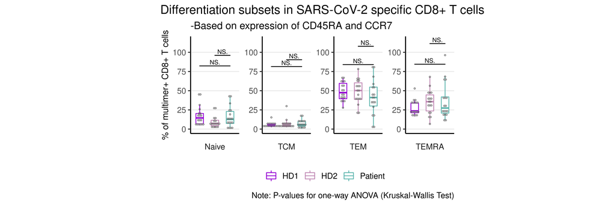

## Figure B

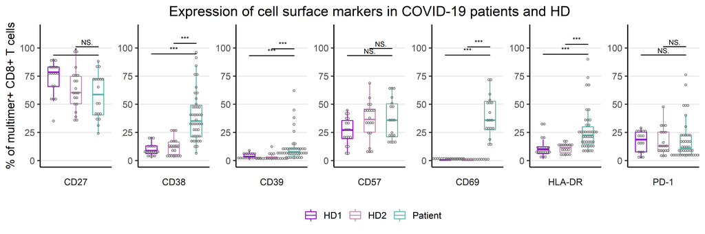

## Figure C

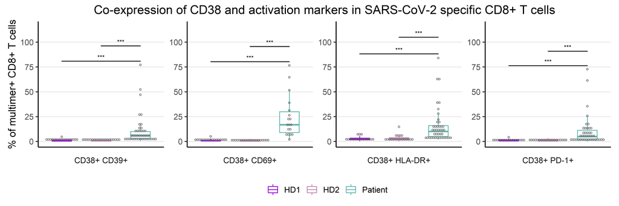

## Figure D

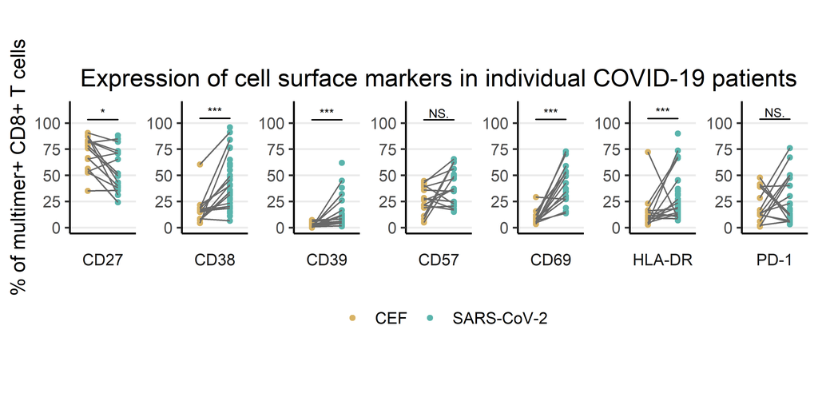

## Figure E

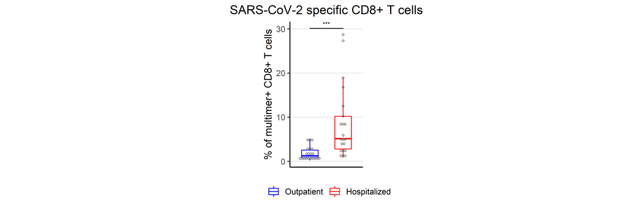

## Figure F

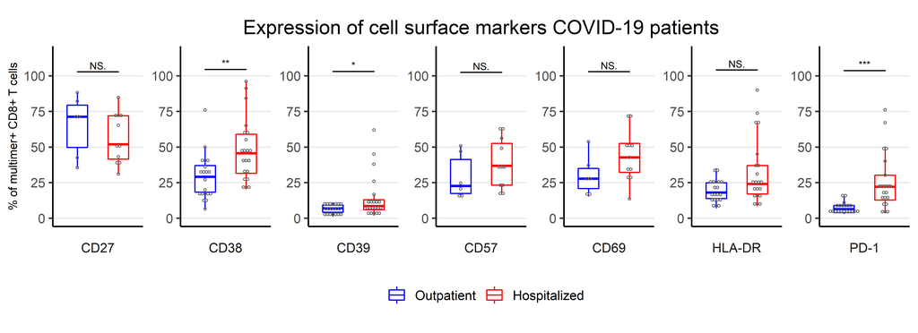

## Figure G

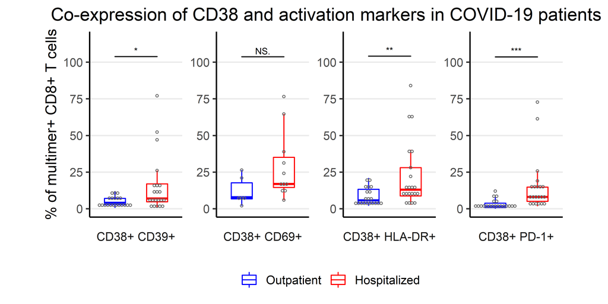

## UMAP visualization

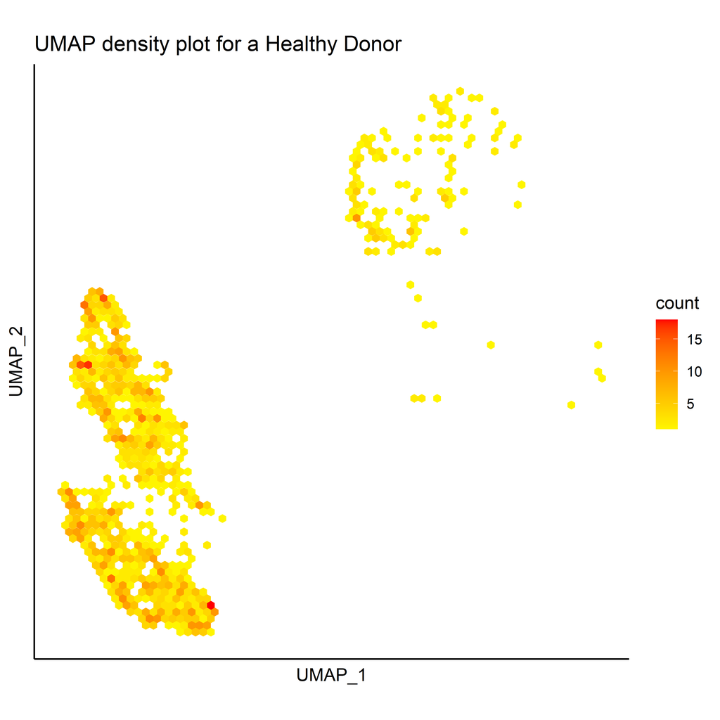

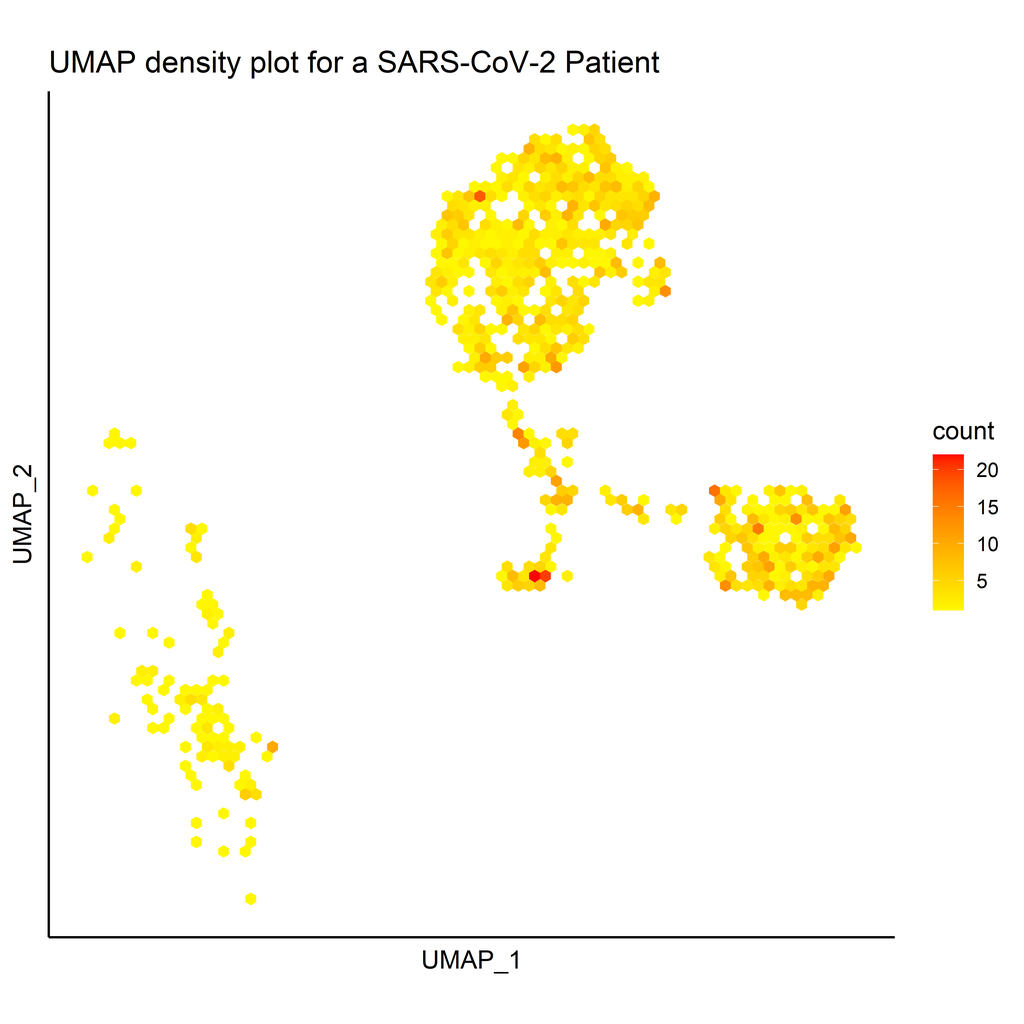

## UMAP visualization

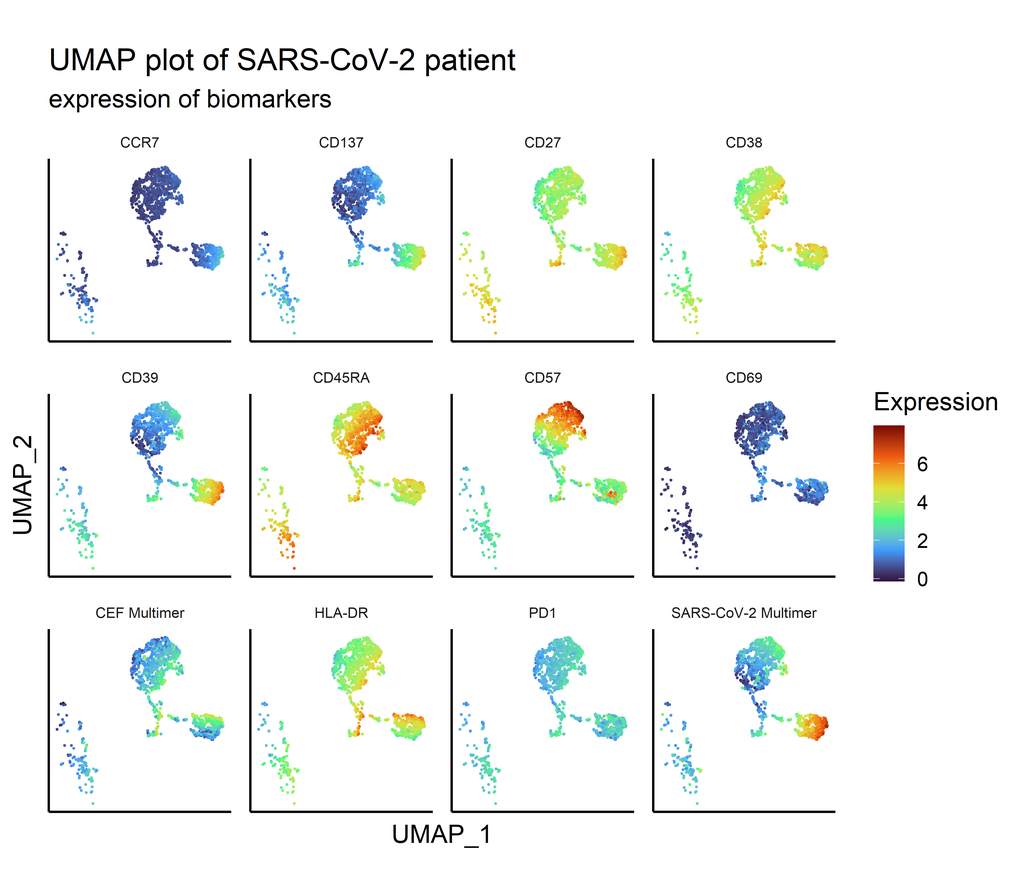

## Conclusion

- Healthy donors showed pre-existing T cell immunity to SARS-CoV-2
- Hospitalized patients showed strong activation profile  
  of SARS-CoV-2-specific T cells
- UMAP for visualization of populations
- R - flexible alternative to FlowJo plugin and visualization tools like GraphPad